# 2026-10-21_p8157_hw-02

Chris

2026-10-21

The project is on GitHub: https://github.com/ChrisW12372/2026-10-21_p8157_hw-02.git

```r
library(tidyverse)
library(splines)
library(nlme)

load("data/MACS-VL.RData")
df <- macsVL
```

# 1 question a

## 1.1 overall variable conditions

```r
person <- df |>
  group_by(id) |>
  summarise(
    vload = first(vload[!is.na(vload)], default = NA_real_),
    n_visits = n_distinct(month[!is.na(cd4) & !is.na(month)]),
    last_month = max(month, na.rm = TRUE),
    .groups = "drop"
  )
```

```r
# baseline CD4
baseline <- df |>
  filter(month == 0) |>
  select(id, baseline_cd4 = cd4)

person <- person |>
  left_join(baseline, by = "id")


df |>
  summarise(
    n_participants = n_distinct(id),
    n_observations = n(),
    n_observed_cd4 = sum(!is.na(cd4))
  )
```

```
##   n_participants n_observations n_observed_cd4
## 1            225           1684           1684
```

```r
summary_table <- person |>
  select(n_visits, last_month, vload, baseline_cd4) |>
  pivot_longer(
    everything(),
    names_to = "Variable",
    values_to = "Value"
  ) |>
  group_by(Variable) |>
  summarise(
    N = sum(!is.na(Value)),
    Missing = sum(is.na(Value)),
    Mean = mean(Value, na.rm = TRUE),
    SD = sd(Value, na.rm = TRUE),
    Median = median(Value, na.rm = TRUE),
    Q1 = quantile(Value, 0.25, na.rm = TRUE),
    Q3 = quantile(Value, 0.75, na.rm = TRUE),
    Min = min(Value, na.rm = TRUE),
    Max = max(Value, na.rm = TRUE),
    .groups = "drop"
  )

summary_table
```

```
## # A tibble: 4 × 10
##   Variable         N Missing     Mean        SD Median    Q1    Q3   Min     Max
##   <chr>        <int>   <int>    <dbl>     <dbl>  <dbl> <dbl> <dbl> <int>   <int>
## 1 baseline_cd4   210      15   804.      347.      761  574.   944   200    3015
## 2 last_month     225       0    42.2       7.93     45   42     47    10      48
## 3 n_visits       225       0     7.48      1.66      8    7      9     3      10
## 4 vload          225       0 78347.   136141.    24573 7928  91195   300 1026656
```

The dataset included 225 participants and 1,684 observations, with no missing CD4 values in the recorded observations. Participants had a median of 8 visits (IQR: 7–9), and the median last follow-up time was 45 months (IQR: 42–47). Baseline CD4 was available for 210 participants, with a median of 761 (IQR: 574.5–944). Baseline viral load was available for all participants and was right-skewed, with a mean of 78,347 and a median of 24,573 (IQR: 7,928–91,195).

## 1.2 baseline viral load

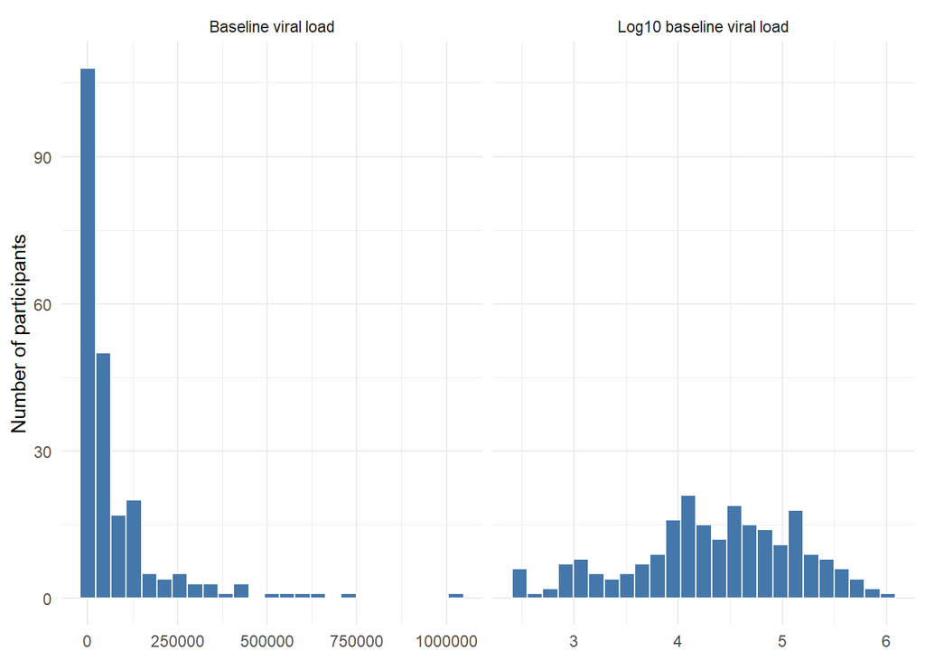

```r
# Extract one baseline viral load value per participant
person <- df |>
  group_by(id) |>
  summarise(
    vload = first(vload[!is.na(vload)], default = NA_real_),
    .groups = "drop"
  )

# Check that all observed viral load values are positive
stopifnot(all(person$vload > 0, na.rm = TRUE))

# Calculate log10 viral load
person <- person |>
  mutate(log10_vload = log10(vload))

# Plot viral load distributions on the original and log10 scales
person |>
  select(vload, log10_vload) |>
  pivot_longer(
    everything(),
    names_to = "Scale",
    values_to = "Viral_load"
  ) |>
  mutate(
    Scale = factor(
      Scale,
      levels = c("vload", "log10_vload"),
      labels = c("Baseline viral load", "Log10 baseline viral load")
    )
  ) |>
  ggplot(aes(x = Viral_load)) +
  geom_histogram(
    bins = 25,
    fill = "#4477AA",
    color = "white",
    na.rm = TRUE
  ) +
  facet_wrap(~ Scale, scales = "free_x") +
  labs(x = NULL, y = "Number of participants") +
  theme_minimal()
```

## 1.3 speghatti plot

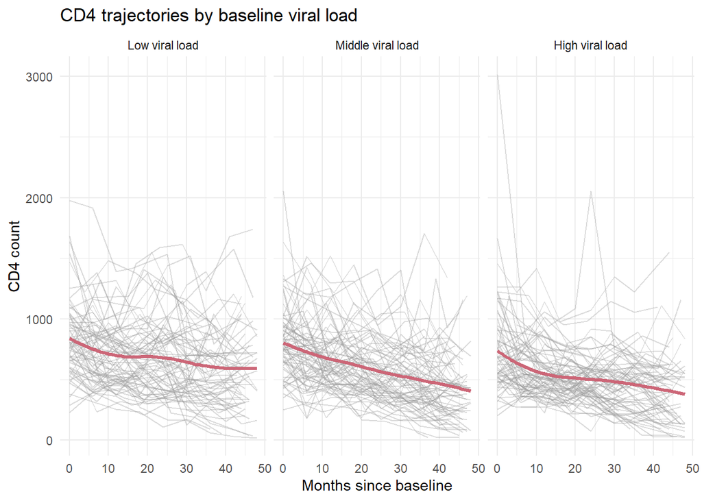

```r
# Define viral load groups using participant-level tertile cutoffs
vl_cutoffs <- quantile(
  person$vload,
  probs = c(1 / 3, 2 / 3),
  na.rm = TRUE,
  names = FALSE
)

person <- person |>
  mutate(
    vl_group = cut(
      vload,
      breaks = c(-Inf, vl_cutoffs, Inf),
      labels = c("Low viral load", "Middle viral load", "High viral load")
    )
  )

# Add viral load groups to the longitudinal data
df_plot <- df |>
  left_join(
    person |> select(id, vl_group),
    by = "id"
  ) |>
  filter(
    !is.na(vl_group),
    !is.na(month),
    !is.na(cd4)
  ) |>
  arrange(id, month)

# Plot individual CD4 trajectories and group-specific smooth trends
ggplot(df_plot, aes(x = month, y = cd4)) +
  geom_line(
    aes(group = id),
    color = "grey60",
    alpha = 0.35,
    linewidth = 0.4
  ) +
  geom_smooth(
    aes(group = 1),
    method = "loess",
    formula = y ~ x,
    se = FALSE,
    color = "#CC6677",
    linewidth = 1.2
  ) +
  facet_wrap(~ vl_group) +
  labs(
    x = "Months since baseline",
    y = "CD4 count",
    title = "CD4 trajectories by baseline viral load"
  ) +
  theme_minimal()
```

Baseline viral load was strongly right-skewed, and the log10 transformation substantially reduced the skewness. CD4 counts generally declined over time in all three viral load groups, with considerable variation across individuals. The middle and high viral load groups showed greater overall declines than the low viral load group, suggesting a possible association between higher baseline viral load and faster CD4 decline.

# 2 question b

```r
# Prepare complete observations for covariance exploration
df_cov <- df |>
  filter(
    !is.na(id),
    !is.na(month),
    !is.na(cd4),
    !is.na(vload),
    vload > 0
  ) |>
  mutate(log10_vload = log10(vload)) |>
  arrange(id, month)

# Fit a flexible mean model before examining covariance
mean_fit <- lm(
  cd4 ~ ns(month, df = 3) * log10_vload,
  data = df_cov
)

# Extract residuals without removing participant-specific differences
df_cov <- df_cov |>
  mutate(resid = residuals(mean_fit))
```

```r
# Group observations into approximately six-month windows
variance_summary <- df_cov |>
  mutate(time_window = 6 * floor(month / 6)) |>
  group_by(time_window) |>
  summarise(
    mean_month = mean(month),
    n_obs = n(),
    residual_variance = var(resid),
    .groups = "drop"
  )

variance_summary
```

```
## # A tibble: 9 × 4
##   time_window mean_month n_obs residual_variance
##         <dbl>      <dbl> <int>             <dbl>
## 1           0      0.885   260           107839.
## 2           6      7.52    219            76902.
## 3          12     13.8     209            62972.
## 4          18     19.8     203            68783.
## 5          24     26.1     202            84819.
## 6          30     32.2     189            79303.
## 7          36     38.0     178            80958.
## 8          42     44.3     186            95440.
## 9          48     48        38            56695.
```

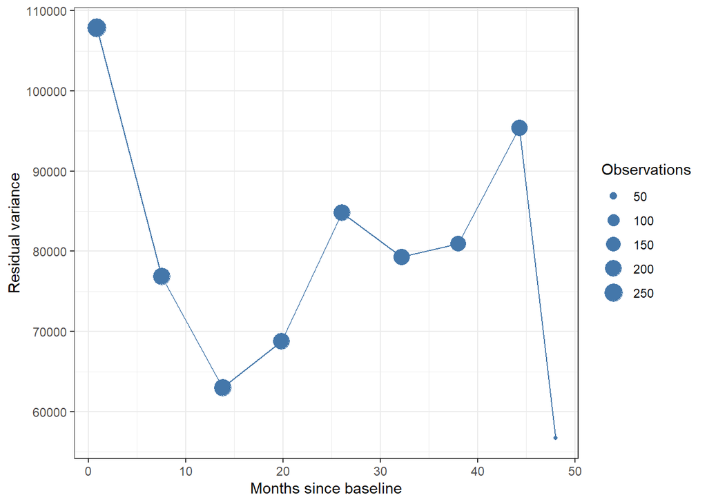

```r
# Plot residual variance over follow-up time
ggplot(
  variance_summary,
  aes(x = mean_month, y = residual_variance)
) +
  geom_line(color = "#4477AA") +
  geom_point(aes(size = n_obs), color = "#4477AA") +
  labs(
    x = "Months since baseline",
    y = "Residual variance",
    size = "Observations"
  ) +
  theme_bw()
```

```r
# Construct all distinct within-participant observation pairs
pair_data <- df_cov |>
  group_by(id) |>
  group_modify(~ {
    if (nrow(.x) < 2) {
      return(tibble(lag = numeric(), semivariance = numeric()))
    }

    pair_index <- combn(seq_len(nrow(.x)), 2)
    j <- pair_index[1, ]
    k <- pair_index[2, ]

    tibble(
      lag = abs(.x$month[j] - .x$month[k]),
      semivariance = 0.5 * (.x$resid[j] - .x$resid[k])^2
    )
  }) |>
  ungroup() |>
  filter(lag > 0)

# Average semivariances within six-month lag intervals
variogram_summary <- pair_data |>
  mutate(lag_window = 6 * floor(lag / 6)) |>
  group_by(lag_window) |>
  summarise(
    mean_lag = mean(lag),
    semivariance = mean(semivariance),
    n_pairs = n(),
    .groups = "drop"
  )

variogram_summary
```

```
## # A tibble: 9 × 4
##   lag_window mean_lag semivariance n_pairs
##        <dbl>    <dbl>        <dbl>   <int>
## 1          0     4.62       18442.     308
## 2          6     7.33       26241.    1392
## 3         12    13.5        31882.    1169
## 4         18    19.7        34581.     954
## 5         24    25.8        40036.     761
## 6         30    31.9        41921.     557
## 7         36    37.9        54565.     380
## 8         42    43.8        59300.     209
## 9         48    48          53689.      37
```

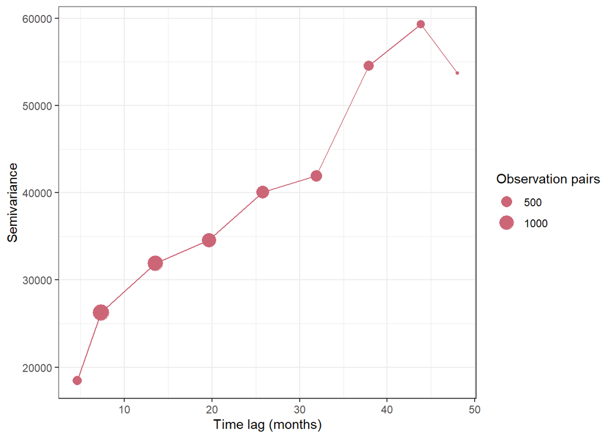

```r
# Plot the empirical variogram
ggplot(
  variogram_summary,
  aes(x = mean_lag, y = semivariance)
) +
  geom_line(color = "#CC6677") +
  geom_point(aes(size = n_pairs), color = "#CC6677") +
  labs(
    x = "Time lag (months)",
    y = "Semivariance",
    size = "Observation pairs"
  ) +
  theme_bw()
```

After adjusting for the mean trajectory and baseline viral load, residual variance varied across follow-up periods without a clear monotonic trend. The estimate at month 48 was based on only 38 observations and should be interpreted cautiously. The empirical variogram generally increased with time lag, suggesting weaker within-participant correlation between measurements taken farther apart, although changing variances may also contribute to this pattern.

A continuous-time AR(1), or exponential correlation structure, is therefore a reasonable candidate given the irregular observation times. Compound symmetry appears less suitable because it assumes constant correlation across time lags. Models allowing time-varying variances could also be considered.

# 3 question c

```r
# Prepare the same analysis sample for both models
df_model <- df |>
  filter(
    !is.na(id),
    !is.na(month),
    !is.na(cd4),
    !is.na(vload),
    vload > 0
  ) |>
  mutate(
    id = factor(id),
    log10_vload_c = log10(vload) - 4
  ) |>
  arrange(id, month)
```

```r
# Fit the model using maximum likelihood
fit_ml <- gls(
  cd4 ~ month * log10_vload_c,
  data = df_model,
  correlation = corCompSymm(form = ~ 1 | id),
  method = "ML"
)
```

```r
# Fit the same model using restricted maximum likelihood
fit_reml <- update(fit_ml, method = "REML")
```

```r
summary(fit_ml)
```

```
## Generalized least squares fit by maximum likelihood
##   Model: cd4 ~ month * log10_vload_c
##   Data: df_model
##        AIC      BIC    logLik
##   22928.55 22961.13 -11458.28
##
## Correlation Structure: Compound symmetry
##  Formula: ~1 | id
##  Parameter estimate(s):
##       Rho
## 0.5672909
##
## Coefficients:
##                        Value Std.Error   t-value p-value
## (Intercept)         779.2651 17.874773  43.59580  0.0000
## month                -6.5912  0.341835 -19.28196  0.0000
## log10_vload_c       -82.2090 20.705429  -3.97041  0.0001
## month:log10_vload_c  -0.8763  0.400088  -2.19021  0.0286
##
##  Correlation:
##                     (Intr) month  lg10__
## month               -0.409
## log10_vload_c       -0.392  0.160
## month:log10_vload_c  0.159 -0.385 -0.412
##
## Standardized residuals:
##        Min         Q1        Med         Q3        Max
## -2.2033453 -0.7040716 -0.1383408  0.5424951  8.3640477
##
## Residual standard error: 283.383
## Degrees of freedom: 1684 total; 1680 residual
```

```r
summary(fit_reml)
```

```
## Generalized least squares fit by REML
##   Model: cd4 ~ month * log10_vload_c
##   Data: df_model
##        AIC      BIC    logLik
##   22914.05 22946.61 -11451.02
##
## Correlation Structure: Compound symmetry
##  Formula: ~1 | id
##  Parameter estimate(s):
##       Rho
## 0.5693312
##
## Coefficients:
##                        Value Std.Error   t-value p-value
## (Intercept)         779.2696 17.921854  43.48153  0.0000
## month                -6.5916  0.341674 -19.29206  0.0000
## log10_vload_c       -82.2067 20.759622  -3.95993  0.0001
## month:log10_vload_c  -0.8762  0.399902  -2.19106  0.0286
##
##  Correlation:
##                     (Intr) month  lg10__
## month               -0.408
## log10_vload_c       -0.392  0.160
## month:log10_vload_c  0.158 -0.385 -0.411
##
## Standardized residuals:
##        Min         Q1        Med         Q3        Max
## -2.1965586 -0.7019290 -0.1379146  0.5408349  8.3385249
##
## Residual standard error: 284.2494
## Degrees of freedom: 1684 total; 1680 residual
```

```r
# Extract coefficient estimates and approximate t-based intervals
extract_results <- function(fit, method_label) {

  tab <- as.data.frame(summary(fit)$tTable)

  residual_df <- fit$dims$N - fit$dims$p
  critical_value <- qt(0.975, df = residual_df)

  tibble(
    Method = method_label,
    Term = rownames(tab),
    Estimate = tab[["Value"]],
    SE = tab[["Std.Error"]],
    CI_lower = Estimate - critical_value * SE,
    CI_upper = Estimate + critical_value * SE,
    p_value = tab[["p-value"]]
  )
}

coef_results <- bind_rows(
  extract_results(fit_ml, "ML"),
  extract_results(fit_reml, "REML")
)

# Display a compact coefficient table
coef_results |>
  mutate(
    across(c(Estimate, SE, CI_lower, CI_upper), ~ round(.x, 3)),
    p_value = format.pval(p_value, digits = 3, eps = 0.001)
  ) |>
  knitr::kable()
```

| Method | Term | Estimate | SE | CI_lower | CI_upper | p_value |
| --- | --- | --- | --- | --- | --- | --- |
| ML | (Intercept) | 779.265 | 17.875 | 744.206 | 814.324 | <0.001 |
| ML | month | -6.591 | 0.342 | -7.262 | -5.921 | <0.001 |
| ML | log10_vload_c | -82.209 | 20.705 | -122.820 | -41.598 | <0.001 |
| ML | month:log10_vload_c | -0.876 | 0.400 | -1.661 | -0.092 | 0.0286 |
| REML | (Intercept) | 779.270 | 17.922 | 744.118 | 814.421 | <0.001 |
| REML | month | -6.592 | 0.342 | -7.262 | -5.921 | <0.001 |
| REML | log10_vload_c | -82.207 | 20.760 | -122.924 | -41.489 | <0.001 |
| REML | month:log10_vload_c | -0.876 | 0.400 | -1.661 | -0.092 | 0.0286 |

```r
# Extract the common within-participant correlation and marginal variance
extract_covariance <- function(fit, method_label) {

  tibble(
    Method = method_label,
    Correlation = unname(
      coef(fit$modelStruct$corStruct, unconstrained = FALSE)
    ),
    Variance = fit$sigma^2,
    SD = fit$sigma
  )
}

cov_results <- bind_rows(
  extract_covariance(fit_ml, "ML"),
  extract_covariance(fit_reml, "REML")
)

cov_results |>
  knitr::kable(digits = 3)
```

| Method | Correlation | Variance | SD |
| --- | --- | --- | --- |
| ML | 0.567 | 80305.95 | 283.383 |
| REML | 0.569 | 80797.74 | 284.249 |

GLS models with compound symmetry gave nearly identical results using ML and REML. Based on REML, participants with a baseline viral load of 10,000 had an estimated mean CD4 count of 779.27 at month 0 (95% CI: 744.12–814.42), with an average decline of 6.59 per month (95% CI: 5.92–7.26).

Each tenfold increase in baseline viral load was associated with a 82.21 lower mean CD4 count at month 0 (95% CI: 41.49–122.92 lower) and an additional decline of 0.88 per month (95% CI: 0.09–1.66; interaction p = 0.0286). Thus, higher baseline viral load was significantly associated with faster CD4 decline under the assumed covariance structure.

The estimated within-participant correlation was 0.569, and the marginal variance was 80,797.74 under REML, compared with 0.567 and 80,305.95 under ML.

# 4 question d

```r
# Extract one viral load value per participant
vl_person <- df_model |>
  distinct(id, vload)

# Calculate participant-level tertile cutoffs
vl_cutoffs <- quantile(
  vl_person$vload,
  probs = c(1 / 3, 2 / 3),
  names = FALSE
)

# Define the low, middle, and high viral load groups
vl_person <- vl_person |>
  mutate(
    vl_group = cut(
      vload,
      breaks = c(-Inf, vl_cutoffs, Inf),
      labels = c("Low", "Middle", "High")
    )
  )
```

```r
# Check the cutoffs and participant counts
vl_cutoffs
```

```
## [1] 11665.33 54907.33
```

```r
count(vl_person, vl_group)
```

```
##   vl_group  n
## 1      Low 75
## 2   Middle 75
## 3     High 75
```

```r
# Add group membership to the longitudinal data
df_cat <- df_model |>
  left_join(
    vl_person |> select(id, vl_group),
    by = "id"
  )

# Use the low viral load group as the reference category
df_cat$vl_group <- relevel(df_cat$vl_group, ref = "Low")
contrasts(df_cat$vl_group) <- contr.treatment(
  levels(df_cat$vl_group),
  base = 1
)
```

```r
# Fit the categorical viral load model using CS and REML
fit_cat <- gls(
  cd4 ~ month * vl_group,
  data = df_cat,
  correlation = corCompSymm(form = ~ 1 | id),
  method = "REML"
)

summary(fit_cat)
```

```
## Generalized least squares fit by REML
##   Model: cd4 ~ month * vl_group
##   Data: df_cat
##        AIC      BIC    logLik
##   22909.58 22952.99 -11446.79
##
## Correlation Structure: Compound symmetry
##  Formula: ~1 | id
##  Parameter estimate(s):
##      Rho
## 0.585048
##
## Coefficients:
##                          Value Std.Error    t-value p-value
## (Intercept)           802.1058  29.23173  27.439556  0.0000
## month                  -5.7009   0.54927 -10.378987  0.0000
## vl_groupMiddle        -21.7193  41.21837  -0.526933  0.5983
## vl_groupHigh         -133.2159  41.40063  -3.217726  0.0013
## month:vl_groupMiddle   -2.5957   0.76222  -3.405422  0.0007
## month:vl_groupHigh     -0.8165   0.78374  -1.041770  0.2977
##
##  Correlation:
##                      (Intr) month  vl_grM vl_grH mnt:_M
## month                -0.400
## vl_groupMiddle       -0.709  0.284
## vl_groupHigh         -0.706  0.282  0.501
## month:vl_groupMiddle  0.288 -0.721 -0.396 -0.203
## month:vl_groupHigh    0.280 -0.701 -0.199 -0.401  0.505
##
## Standardized residuals:
##        Min         Q1        Med         Q3        Max
## -1.9866415 -0.7166885 -0.1512801  0.5280207  8.1185037
##
## Residual standard error: 288.9831
## Degrees of freedom: 1684 total; 1678 residual
```

```r
# Reuse the coefficient extraction function from part (c)
cat_results <- extract_results(fit_cat, "REML")

cat_results |>
  mutate(
    across(c(Estimate, SE, CI_lower, CI_upper), ~ round(.x, 3)),
    p_value = format.pval(p_value, digits = 3, eps = 0.001)
  ) |>
  knitr::kable()
```

| Method | Term | Estimate | SE | CI_lower | CI_upper | p_value |
| --- | --- | --- | --- | --- | --- | --- |
| REML | (Intercept) | 802.106 | 29.232 | 744.771 | 859.440 | < 0.001 |
| REML | month | -5.701 | 0.549 | -6.778 | -4.624 | < 0.001 |
| REML | vl_groupMiddle | -21.719 | 41.218 | -102.564 | 59.125 | 0.59831 |
| REML | vl_groupHigh | -133.216 | 41.401 | -214.418 | -52.014 | 0.00132 |
| REML | month:vl_groupMiddle | -2.596 | 0.762 | -4.091 | -1.101 | < 0.001 |
| REML | month:vl_groupHigh | -0.816 | 0.784 | -2.354 | 0.721 | 0.29767 |

```r
# Extract the covariance parameter estimates
extract_covariance(fit_cat, "REML") |>
  knitr::kable(digits = 3)
```

| Method | Correlation | Variance | SD |
| --- | --- | --- | --- |
| REML | 0.585 | 83511.22 | 288.983 |

```r
# Perform Wald F-tests for the model terms
wald_results <- anova(fit_cat, type = "marginal")

wald_results
```

```
## Denom. DF: 1678
##                numDF  F-value p-value
## (Intercept)        1 752.9292  <.0001
## month              1 107.7234  <.0001
## vl_group           2   5.9615  0.0026
## month:vl_group     2   6.1071  0.0023
```

```r
# Extract the joint test of the time-by-group interaction
wald_results[
  "month:vl_group",
  ,
  drop = FALSE
]
```

```
## Denom. DF: 1678
##                numDF  F-value p-value
## month:vl_group     2 6.107087  0.0023
```

Baseline viral load was divided into tertiles using cutoffs of 11,665.33 and 54,907.33, with 75 participants per group. A GLS model with compound symmetry was fitted using REML.

In the low viral load group, the estimated mean CD4 count at month 0 was 802.11, with an average decline of 5.70 per month. Compared with this group, baseline CD4 was 21.72 lower in the middle group (95% CI: −102.56 to 59.13; p = 0.598) and 133.22 lower in the high group (95% CI: −214.42 to −52.01; p = 0.0013).

The middle group declined by an additional 2.60 per month compared with the low group (95% CI: −4.09 to −1.10; p < 0.001). The high group declined by an additional 0.82 per month, although this difference was not significant (95% CI: −2.35 to 0.72; p = 0.298). The estimated monthly slopes were −5.70, −8.30, and −6.52 for the low, middle, and high groups, respectively.

The joint test of the time-by-group interaction was significant (F(2, 1678) = 6.11; p = 0.0023), indicating an association between baseline viral load category and CD4 decline under the CS model. However, the estimated decline did not increase monotonically across categories. The estimated within-participant correlation was 0.585.

# 5 question e

```r
# Use log10 baseline viral load as the spline predictor
df_vc <- df_model |>
  mutate(x = log10(vload))

# Choose knots using one observation per participant
person_x <- df_vc |>
  distinct(id, x)

internal_knots <- quantile(
  person_x$x,
  probs = c(1 / 3, 2 / 3),
  names = FALSE
)

boundary_knots <- range(person_x$x)

# Construct a natural cubic spline with two internal knots
spline_basis <- ns(
  df_vc$x,
  knots = internal_knots,
  Boundary.knots = boundary_knots
)

# Add the three spline basis variables
df_vc <- df_vc |>
  mutate(
    s1 = spline_basis[, 1],
    s2 = spline_basis[, 2],
    s3 = spline_basis[, 3]
  )

# Allow both the intercept and time slope to depend on viral load
fit_vc <- gls(
  cd4 ~ month * (s1 + s2 + s3),
  data = df_vc,
  correlation = corCompSymm(form = ~ 1 | id),
  method = "REML"
)

summary(fit_vc)
```

```
## Generalized least squares fit by REML
##   Model: cd4 ~ month * (s1 + s2 + s3)
##   Data: df_vc
##        AIC      BIC    logLik
##   22883.03 22937.27 -11431.51
##
## Correlation Structure: Compound symmetry
##  Formula: ~1 | id
##  Parameter estimate(s):
##       Rho
## 0.5666691
##
## Coefficients:
##                 Value Std.Error   t-value p-value
## (Intercept)  973.4072  69.72844 13.959975  0.0000
## month         -4.2410   1.33602 -3.174368  0.0015
## s1          -226.1310  69.49586 -3.253877  0.0012
## s2          -452.4664 170.11916 -2.659703  0.0079
## s3          -154.0788  90.93589 -1.694367  0.0904
## month:s1      -1.1272   1.32410 -0.851294  0.3947
## month:s2      -6.7460   3.25722 -2.071099  0.0385
## month:s3      -3.1807   1.74891 -1.818651  0.0691
##
##  Correlation:
##          (Intr) month  s1     s2     s3     mnth:1 mnth:2
## month    -0.409
## s1       -0.299  0.123
## s2       -0.919  0.376  0.019
## s3       -0.347  0.143 -0.218  0.569
## month:s1  0.123 -0.302 -0.416 -0.006  0.091
## month:s2  0.376 -0.919 -0.006 -0.410 -0.237  0.024
## month:s3  0.142 -0.341  0.090 -0.236 -0.417 -0.201  0.565
##
## Standardized residuals:
##        Min         Q1        Med         Q3        Max
## -2.6145657 -0.6949101 -0.1334415  0.5337299  8.1650702
##
## Residual standard error: 283.4428
## Degrees of freedom: 1684 total; 1676 residual
```

```r
# Display knot locations on the original viral load scale
10^internal_knots
```

```
## [1] 11664.44 54907.00
```

```r
# Estimate the monthly CD4 slope at specified log10 viral load values
estimate_slope <- function(x_values) {

  # Evaluate the original spline basis at new predictor values
  new_basis <- predict(spline_basis, newx = x_values)

  beta <- coef(fit_vc)
  V <- vcov(fit_vc)

  # Construct contrasts for the time slope
  L <- matrix(
    0,
    nrow = length(x_values),
    ncol = length(beta),
    dimnames = list(NULL, names(beta))
  )

  L[, "month"] <- 1

  interaction_names <- paste0("month:s", 1:3)
  L[, interaction_names] <- new_basis

  # Calculate estimates and standard errors using the full covariance matrix
  slope <- as.vector(L %*% beta)
  slope_se <- sqrt(rowSums((L %*% V) * L))

  residual_df <- fit_vc$dims$N - fit_vc$dims$p
  critical_value <- qt(0.975, df = residual_df)

  tibble(
    log10_vload = x_values,
    vload = 10^x_values,
    slope = slope,
    SE = slope_se,
    lower = slope - critical_value * slope_se,
    upper = slope + critical_value * slope_se
  )
}

# Evaluate the slope across the observed viral load range
slope_grid <- estimate_slope(
  seq(
    min(person_x$x),
    max(person_x$x),
    length.out = 200
  )
)
```

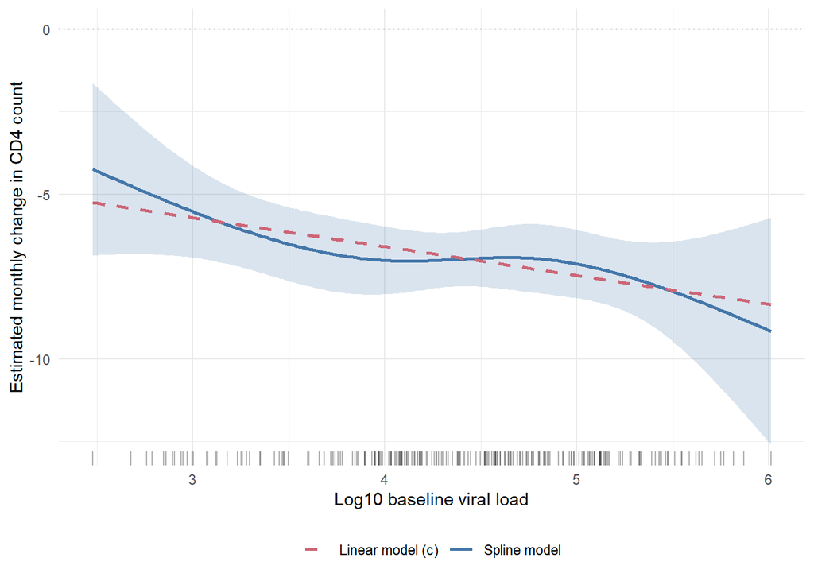

```r
# Calculate the slope implied by the linear model in part (c)
beta_c <- coef(fit_reml)

slope_grid <- slope_grid |>
  mutate(
    linear_slope =
      beta_c[["month"]] +
      beta_c[["month:log10_vload_c"]] * (log10_vload - 4)
  )

# Plot the varying slope and pointwise confidence intervals
ggplot(slope_grid, aes(x = log10_vload)) +
  geom_ribbon(
    aes(ymin = lower, ymax = upper),
    fill = "#4477AA",
    alpha = 0.2
  ) +
  geom_hline(
    yintercept = 0,
    color = "grey50",
    linetype = "dotted"
  ) +
  geom_line(
    aes(y = slope, color = "Spline model"),
    linewidth = 1
  ) +
  geom_line(
    aes(y = linear_slope, color = "Linear model (c)"),
    linewidth = 1,
    linetype = "dashed"
  ) +
  geom_rug(
    data = person_x,
    aes(x = x),
    inherit.aes = FALSE,
    alpha = 0.3
  ) +
  scale_color_manual(
    values = c(
      "Spline model" = "#4477AA",
      "Linear model (c)" = "#CC6677"
    )
  ) +
  labs(
    x = "Log10 baseline viral load",
    y = "Estimated monthly change in CD4 count",
    color = NULL
  ) +
  theme_minimal() +
  theme(legend.position = "bottom")
```

```r
# Estimate slopes at selected baseline viral load values
specific_slopes <- estimate_slope(
  log10(c(1000, 10000, 100000))
)

specific_slopes |>
  select(vload, slope, lower, upper) |>
  knitr::kable(digits = 3)
```

| vload | slope | lower | upper |
| --- | --- | --- | --- |
| 1e+03 | -5.531 | -6.927 | -4.135 |
| 1e+04 | -7.013 | -8.045 | -5.981 |
| 1e+05 | -7.121 | -8.160 | -6.082 |

A varying coefficient model was fitted using natural cubic splines with two internal knots, compound symmetry, and REML. The estimated monthly CD4 changes at baseline viral loads of 1,000, 10,000, and 100,000 were −5.53 (95% CI: −6.93 to −4.14), −7.01 (−8.05 to −5.98), and −7.12 (−8.16 to −6.08), respectively. Thus, participants with these viral loads were estimated to lose approximately 5.5–7.1 CD4 cells per month on average.

The estimated slope generally became more negative as viral load increased, with some flattening at intermediate values. Although the spline curve showed modest curvature, the fitted line from part (c) remained within its pointwise 95% confidence band across the plotted range. The plot therefore suggests that the linear specification in part (c) is a reasonable approximation. Estimates at the extremes were less precise because fewer participants had these viral loads.